# Unit1_Assignment_StockDynamics

Anuranjan

23 September 2016

#### In this problem, we’ll take a look at how the stock dynamics of companies:IBM, General Electric (GE), Procter and Gamble, Coca Cola, and Boeing have changed over time.Each data frame has two variables, described as follows:

Date: the date of the stock price, always given as the first of the ‘month’.  
StockPrice: the average stock price of the company in the given month.

# Reading CSV files.

```r
IBM = read.csv('IBMStock.csv')
GE = read.csv("GEStock.csv")
ProcterGamble = read.csv("ProcterGambleStock.csv")
CocaCola = read.csv("CocaColaStock.csv")
Boeing = read.csv("BoeingStock.csv")
summary(IBM)
```

```
##       Date       StockPrice
##  1/1/00 :  1   Min.   : 43.40
##  1/1/01 :  1   1st Qu.: 88.34
##  1/1/02 :  1   Median :112.11
##  1/1/03 :  1   Mean   :144.38
##  1/1/04 :  1   3rd Qu.:165.41
##  1/1/05 :  1   Max.   :438.90
##  (Other):474
```

```r
str(IBM)
```

```
## 'data.frame':    480 obs. of  2 variables:
##  $ Date      : Factor w/ 480 levels "1/1/00","1/1/01",..: 11 171 211 251 291 331 371 411 451 51 ...
##  $ StockPrice: num  360 347 327 320 270 ...
```

```r
head(IBM)
```

```
##     Date StockPrice
## 1 1/1/70   360.3190
## 2 2/1/70   346.7237
## 3 3/1/70   327.3457
## 4 4/1/70   319.8527
## 5 5/1/70   270.3752
## 6 6/1/70   267.2050
```

# Since Date variable is stored as factor, converting it to Date object.

```r
IBM$Date=as.Date(IBM$Date,'%m/%d/%y')
GE$Date=as.Date(GE$Date,'%m/%d/%y')
ProcterGamble$Date=as.Date(ProcterGamble$Date,'%m/%d/%y')
CocaCola$Date=as.Date(CocaCola$Date,'%m/%d/%y')
Boeing$Date=as.Date(Boeing$Date,'%m/%d/%y')
str(IBM)
```

```
## 'data.frame':    480 obs. of  2 variables:
##  $ Date      : Date, format: "1970-01-01" "1970-02-01" ...
##  $ StockPrice: num  360 347 327 320 270 ...
```

```r
head(IBM)
```

```
##         Date StockPrice
## 1 1970-01-01   360.3190
## 2 1970-02-01   346.7237
## 3 1970-03-01   327.3457
## 4 1970-04-01   319.8527
## 5 1970-05-01   270.3752
## 6 1970-06-01   267.2050
```

# STR() function shows us that there are 480 observations.

# Earliest year in our dataset.

```r
c(min(IBM$Date), min(GE$Date), min(ProcterGamble$Date), min(CocaCola$Date) , min(Boeing$Date))
```

```
## [1] "1970-01-01" "1970-01-01" "1970-01-01" "1970-01-01" "1970-01-01"
```

# Latest year in our dataset.

```r
c(max(IBM$Date), max(GE$Date), max(ProcterGamble$Date), max(CocaCola$Date) , max(Boeing$Date))
```

```
## [1] "2009-12-01" "2009-12-01" "2009-12-01" "2009-12-01" "2009-12-01"
```

# Mean Stock Price

```r
c(mean(IBM$StockPrice), mean(GE$StockPrice), mean(ProcterGamble$StockPrice), mean(CocaCola$StockPrice) , mean(Boeing$StockPrice))
```

```
## [1] 144.37503  59.30350  77.70452  60.02973  46.59293
```

# Max Stock Price

```r
c(max(IBM$StockPrice), max(GE$StockPrice), max(ProcterGamble$StockPrice), max(CocaCola$StockPrice) , max(Boeing$StockPrice))
```

```
## [1] 438.9016 156.8437 149.6200 146.5843 107.2800
```

# Min Stock Price

```r
c(min(IBM$StockPrice), min(GE$StockPrice), min(ProcterGamble$StockPrice), min(CocaCola$StockPrice) , min(Boeing$StockPrice))
```

```
## [1] 43.395000  9.293636 46.884545 30.057143 12.736364
```

# Median Stock Price

```r
c(median(IBM$StockPrice), median(GE$StockPrice), median(ProcterGamble$StockPrice), median(CocaCola$StockPrice) , median(Boeing$StockPrice))
```

```
## [1] 112.11460  55.81205  78.33608  51.43699  44.88340
```

# Std Dev of Stock Price

```r
c(sd(IBM$StockPrice), sd(GE$StockPrice), sd(ProcterGamble$StockPrice), sd(CocaCola$StockPrice) , sd(Boeing$StockPrice))
```

```
## [1] 87.82208 23.99255 18.19414 25.16629 19.89184
```

# Generating plot for CocaCola. Adding arguement type=“l” generates line instead of points.

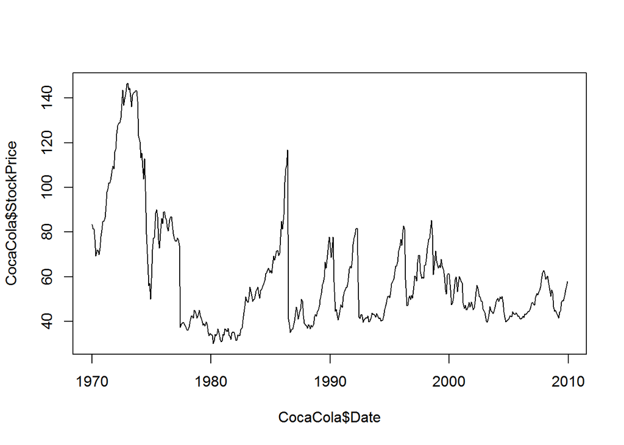

```r
plot(CocaCola$Date,CocaCola$StockPrice, type = "l")
```

# Adding a new line to the plot by using the lines function instead of the plot function. Adding colours to the lines as well to distinguish better.

Note:In R markdown, we need to execute ‘plot’ and ‘lines’ command in same R-box, otherwise it would give error “plot.new has not been called yet.”

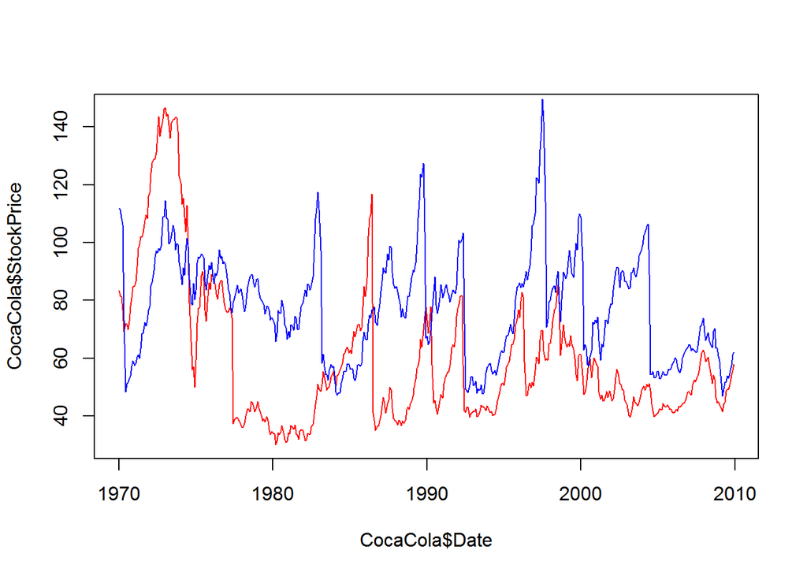

```r
plot(CocaCola$Date,CocaCola$StockPrice, type = "l",col="red")
lines(ProcterGamble$Date, ProcterGamble$StockPrice,col="blue")
```

# Instead we could also have changed the line type of one to distinguish better. We can draw vertical/horizontal line to make comparisons

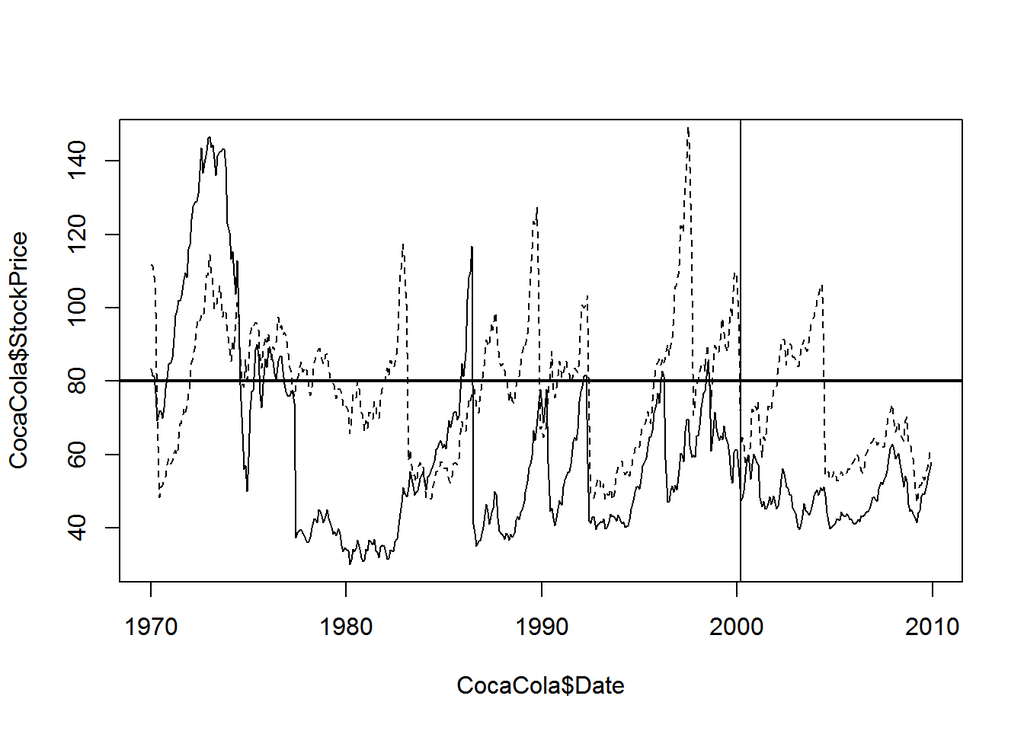

```r
plot(CocaCola$Date,CocaCola$StockPrice, type = "l")
lines(ProcterGamble$Date, ProcterGamble$StockPrice,lty=2)
abline(v=as.Date(c("2000-03-01")), lwd=1)
abline(h=80, lwd=2)
```

# Visualizing stock prices changed from 1995-2005 for all five companies.

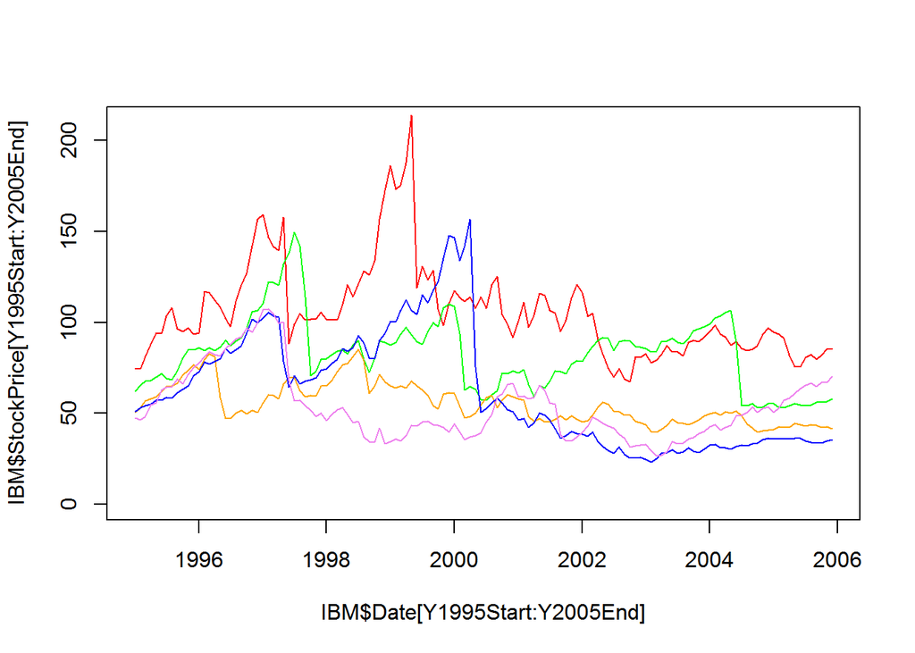

```r
Y1995Start=which(IBM$Date=='1995-01-01')
Y2005End=which(IBM$Date=='2005-12-01')
plot(IBM$Date[Y1995Start:Y2005End], IBM$StockPrice[Y1995Start:Y2005End], type="l", col="red", ylim=c(0,210))
lines(ProcterGamble$Date[Y1995Start:Y2005End], ProcterGamble$StockPrice[Y1995Start:Y2005End], col="green" )
lines(CocaCola$Date[Y1995Start:Y2005End], CocaCola$StockPrice[Y1995Start:Y2005End] , col="orange")
lines(GE$Date[Y1995Start:Y2005End], GE$StockPrice[Y1995Start:Y2005End], col="blue")
lines(Boeing$Date[Y1995Start:Y2005End], Boeing$StockPrice[Y1995Start:Y2005End], col="violet")
```

```r
#abline(v=as.Date(c("1997-09-01","1997-11-01")),lwd=.1)
```

By looking at this plot, we can see that the stock for General Electric falls significantly more than the other stocks after the technology bubble burst and IBM has the highest value, around 1999.

# Stocks trends during each month

```r
tapply(IBM$StockPrice,months(IBM$Date),mean)
```

```
##     April    August  December  February   January      July      June
##  152.1168  140.1455  140.7593  152.6940  150.2384  139.0670  139.0907
##     March       May  November   October September
##  152.4327  151.5022  138.0187  137.3466  139.0885
```

```r
tapply(GE$StockPrice,months(GE$Date),mean)
```

```
##     April    August  December  February   January      July      June
##  64.48009  56.50315  59.10217  62.52080  62.04511  56.73349  56.46844
##     March       May  November   October September
##  63.15055  60.87135  57.28879  56.23897  56.23913
```

```r
tapply(ProcterGamble$StockPrice,months(ProcterGamble$Date),mean)
```

```
##     April    August  December  February   January      July      June
##  77.68671  76.82266  78.29661  79.02575  79.61798  76.64556  77.39275
##     March       May  November   October September
##  77.34761  77.85958  78.45610  76.67903  76.62385
```

```r
tapply(Boeing$StockPrice,months(Boeing$Date),mean)
```

```
##     April    August  December  February   January      July      June
##  47.04686  46.86311  46.17315  46.89223  46.51097  46.55360  47.38525
##     March       May  November   October September
##  46.88208  48.13716  45.14990  45.21603  46.30485
```

```r
tapply(CocaCola$StockPrice,months(CocaCola$Date),mean)
```

```
##     April    August  December  February   January      July      June
##  62.68888  58.88014  59.73223  60.73475  60.36849  58.98346  60.81208
##     March       May  November   October September
##  62.07135  61.44358  59.10268  57.93887  57.60024
```

**After seeing these trends, we are ready to buy stock in certain months and sell it in others! But, we should be careful, because one really good or really bad year could skew the average to show a trend that is not really there in general.**

# Trying the above summary in the same graph. Not working, need to try more.

```r
plotStockByMonth <- function(company,LineCol){
  stockByMonth = tapply(company$StockPrice,format(company$Date, "%m"),mean)
  stockByMonthDF = as.data.frame(stockByMonth)
  names(stockByMonthDF)=c("AvgStockPrice")
  stockByMonthDF$month = names(stockByMonth)
  if(count==0){
    plot(stockByMonthDF$month,stockByMonthDF$AvgStockPrice, col=LineCol,type = "l")
    count <<- count + 1
  } else {
    lines(stockByMonthDF$month,stockByMonthDF$AvgStockPrice, col=LineCol)
    count <<- count + 1
  }

}
count=1
plot.new()
plotStockByMonth(IBM,"red")
plotStockByMonth(GE,"orange")
plotStockByMonth(ProcterGamble,"green")
plotStockByMonth(Boeing,"blue")
plotStockByMonth(CocaCola,"yellow")
```

```r
count
```

```
## [1] 6
```